# E.Coli: ein typischer Gastroenteritis-Erreger

Jakob Schumacher

25. Januar 2022

# Jakob Schumacher

- Hygienereferent im Gesundheitsamt Reinickendorf
- Zuvor:
  - Robert Koch-Institut
  - Bundesministerium für Gesundheit
  - Medizin (Krankenhaus, Gefängnis)

# Überblick über Montag und Mittwoch

1. Überblick über Gastroenteritis
2. E.Coli ausführlich
3. Erreger bearbeiten: Trello-Board
4. Board durchgehen
5. Walk and Talk

# Teil 1

Überblilck über Gastroenteritis Erreger

# Gastroenteritis-Erreger

- Norovirus
- Rotavirus
- Salmonellen
- Campylobacter
- Shigellen
- E.Coli
- Yersiniose
- Listeriose
- Giardia
- Kryptosporidiose

# Die wichtigsten Punkte bei Gastroenteritis-Erregern

- Gestroenteritis-Erreger sind häufig
- Viele Ausbrüche
- Gefährlichster Erreger: EHEC/HUS

# Der Darm

- 4-5 Meter lang
- Wichtigste Aufgabe: Verdauung, Immunabwehr und ?
- Enthält 1-2 Kilogramm Bakterien (Mikrobiom)
- Das Mikrobiom spielt eine größere Rolle als bislang gedacht

# Was muss man zu einem Erreger wissen

1. Namen des Erregers und Krankheit
2. Epidemiologie
3. Vorkommen
4. Umweltresistenz
5. Übertragungswege
6. Zeiten
7. Labornachweise
8. Meldepflichten
9. Infektionsinterview-Fragen
10. Maßnahmen

# Teil 2

E.Coli und seine Krankheiten

# Überblick über E.Coli

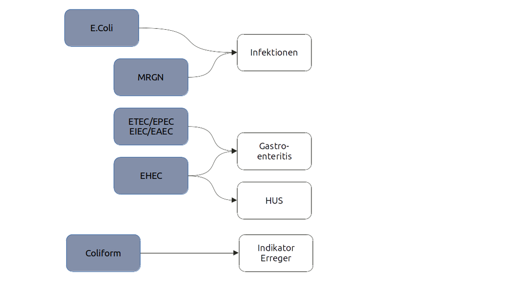

# Gastroenteritis-Symptome

- Krankheitsgefühl
- Bauchschmerzen
- Durchfall
- Erbrechen
- Fieber
- Schmerzen
- Blut im Stuhl

# Hämolytisch-Urämische Symptome (HUS)

- Anämie (Blutarmut)
- Urämie (Nierenversagen)
- Thrombozytopenie (Blutung)
- Neurologische Symptome

# Infektionen

- Wundinfektion
- Harnwegsinfektionen
- Sepsis

# E.Coli und die Toxine

- E.Coli hat diverse Mechanismen/Toxine
- Manche Mechanismen schützen vor Antibiotika
- Manche Mechanismen verursachen eine besser Anheftung oder Eindringung in die Zelle
- Shigatoxin 2 (nur EHEC) verursacht ein HUS

# Epidemiologie

- Massive Inzidenzen in Ländern mit hygienisch niedrigen Standards
- Deutschland
  - ~10.000 E.Coli-Enteritis
  - ~1000 Ehec
  - ~100 HUS
- Kinder und Reiserückkehrer

# Vorkommen

- E.Coli lebt im Enddarm von vielen Warmblütern
- Weltweit vertreten
- EHEC vor allem in Wiederkäuern: Rinder, Schafe, Ziegen

# Umweltverhalten

- E.Coli lebt im Darm von Tieren
- Von dort auf das Fell und die Umgebung
- Vom Fell beim Schlachten aufs Fleisch
- Vom Fell auf die Hand
- Vom Darm auf die Felder
- Vom Darm ins Wasser
- Vom Wasser aufs Feld

# Wichtigste Übertragung auf Menschen

- Kontaktinfektion (Schmierinfektion)
  - Übertragung über Hände (Streichelzoo)
  - Fäkal-Oral
- Lebensmittel
- Trinkwasser

# Zeiten

- Inkubationszeit: 2-10 Tage
- Ansteckungsfähige Zeit: Solange Symptome bestehen. Aber Dauerausscheidung möglich

# Labornachweise

- Kultur (Goldstandard)
- PCR (Weißt die Gene nach)
- ELISA (Weißt die Toxine nach)
- Genomsequenzierung

# E.Coli erscheint als folgende Meldung

- HUS (Arzt)
- EHEC (Labor)
- E.Coli-Enteritis (Labor, §33, § 36, §42)
- Wasserkeim (TrinkWV)
- MRGN (Labor)
- Wundinfektionskeim (Fehlmeldung)

# Maßnahmen EHEC I

- Informationsbeschaffung, Übermittlung, Informationsweitergabe (Lebensmittelaufsicht)
- Ausbruchsuntersuchung
- Aufklärung
  - Erreger
  - Küchenhygiene
  - Toilettenhygiene.
  - Händehygiene
  - Wäschehygiene
  - Lebensmittelhygiene auf Reisen
  - Streichelzoo

# Maßnahmen EHEC II

- Isolierung der erkrankten Person in einer Einrichtung
- Tätigkeitsverbot nach § 34
- Tätigkeitsverbot nach § 42

# Infektionsinterview-Fragen I

- Welche Krankheitszeichen sind bei Ihnen aufgetreten?
- Wann hat die Erkrankung genau begonnen?
- Sind in Ihrem Umfeld weitere Personen erkrankt?
- Haben Sie eine Verbindung zu einer Kita oder ähnlichen Einrichtung?
- Haben Sie eine Verbindung zu einer Einrichtung, in der sehr viele Menschen untergebracht sind?

# Infektionsinterview-Fragen II

- Wohnen Sie mit jemand zusammen, der in eine Kita oder Schule geht oder dort arbeitet?
- Haben Sie beruflich mit Lebensmitteln zu tun?
- Waren Sie vor der Erkrankung im Ausland?
- Waren sie vor Erkrankungsbeginn im Kontakt mit Wiederkäuern?

# Teil 3 + 4

[Trello-Board](https://trello.com/b/jhUvwVfx/hygko-67-68)

# Vielen Dank

- Bilder von
  - https://unsplash.com/photos/13UugSL9q7A

```
## [1] FALSE
```

```
## [1] FALSE
```